# Seattle University: Center for Community Engagement

Senior Data and Evaluation Analyst Interview

Prepared by: James Lamar Foster

# Youth Initiative Zone Schools and Students

Respondents by School

| School Name | Group | Percent (Total) |
| --- | --- | --- |
| 21st Century K-8 School | SUYI | 3.3% (29) |
| 21st Century K-8 School | SUYI-Focus | 0.6% (5) |
| Cascade High School | SUYI | 1.0% (9) |
| Franklin Elementary | SUYI | 1.0% (9) |
| Franklin Elementary | SUYI-Focus | 0.5% (4) |
| Horizon Middle School | SUYI | 13.3% (117) |
| Horizon Middle School | SUYI-Focus | 4.7% (41) |
| Jackson High School | SUYI | 14.5% (128) |
| Jackson High School | SUYI-Focus | 4.0% (35) |
| Johnson High School | SUYI | 2.0% (18) |
| Johnson High School | SUYI-Focus | 0.7% (6) |
| Kennedy Elementary | SUYI | 5.2% (46) |
| Kennedy Elementary | SUYI-Focus | 0.2% (2) |
| King K-8 School | SUYI | 4.7% (41) |
| King K-8 School | SUYI-Focus | 1.5% (13) |
| Lincoln Elementary | SUYI | 11.2% (99) |
| Lincoln Elementary | SUYI-Focus | 4.7% (41) |
| Monroe Elementary | SUYI | 5.1% (45) |
| Monroe Elementary | SUYI-Focus | 3.1% (27) |
| New Future Alternative | SUYI | 2.0% (18) |
| New Future Alternative | SUYI-Focus | 0.9% (8) |
| Olympic High School | SUYI | 0.5% (4) |
| Olympic High School | SUYI-Focus | 1.1% (10) |
| Sound View Middle School | SUYI | 2.0% (18) |
| Sound View Middle School | SUYI-Focus | 0.6% (5) |
| Spring Crest Elementary | SUYI | 3.4% (30) |
| Spring Crest Elementary | SUYI-Focus | 2.0% (18) |
| Union Middle School | SUYI | 0.3% (3) |
| Union Middle School | SUYI-Focus | 0.7% (6) |
| Valley Elementary | SUYI | 4.7% (41) |
| Valley Elementary | SUYI-Focus | 0.6% (5) |
| Total | - | 100.0% (881) |

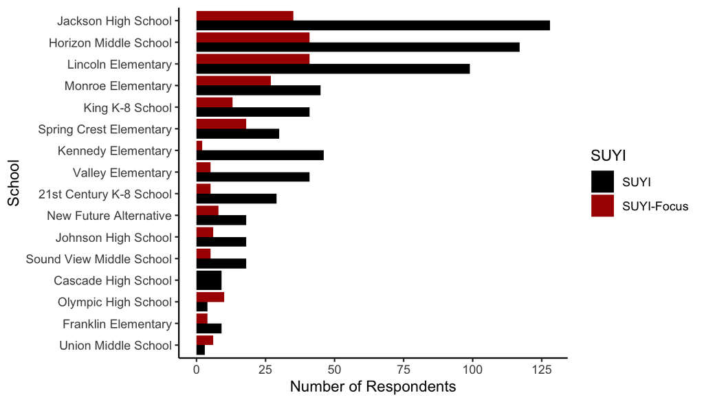

# Youth Initiative Zone Student Demographics

Student’s Sex

| Group | Sex | Percent (Total) |
| --- | --- | --- |
| SUYI | Female | 35.9% (316) |
| SUYI | Male | 38.5% (339) |
| SUYI-Focus | Female | 13.2% (116) |
| SUYI-Focus | Male | 12.5% (110) |

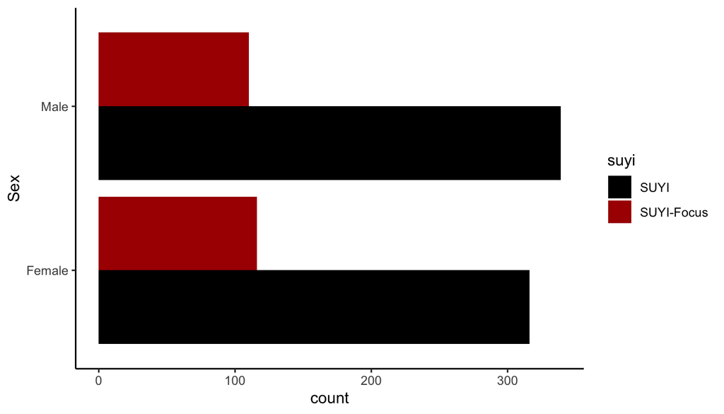

| Group | Racial Identity | Percent (Total) |
| --- | --- | --- |
| SUYI | African American/Black | 34.3% (302) |
| SUYI | Asian Indian | 0.2% (2) |
| SUYI | Chinese | 13.1% (115) |
| SUYI | Filipino | 2.2% (19) |
| SUYI | Japanese | 0.5% (4) |
| SUYI | Korean | 0.2% (2) |
| SUYI | Other American Indian | 7.6% (67) |
| SUYI | Other Asian | 1.0% (9) |
| SUYI | Samoan | 0.2% (2) |
| SUYI | Vietnamese | 5.3% (47) |
| SUYI | White | 9.8% (86) |
| SUYI-Focus | African American/Black | 14.5% (128) |
| SUYI-Focus | Alaska Native | 0.3% (3) |
| SUYI-Focus | Cambodian | 0.1% (1) |
| SUYI-Focus | Chinese | 0.5% (4) |
| SUYI-Focus | Filipino | 0.2% (2) |
| SUYI-Focus | Other American Indian | 1.8% (16) |
| SUYI-Focus | Other Asian | 0.8% (7) |
| SUYI-Focus | Vietnamese | 6.1% (54) |
| SUYI-Focus | White | 1.2% (11) |

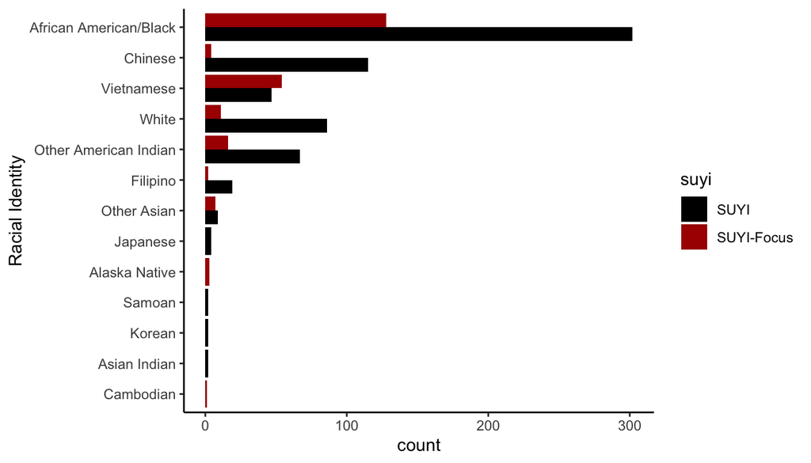

Student’s Primary Language

| Group | Primary Language | Percent (Total) |
| --- | --- | --- |
| SUYI | Amharic | 3.9% (19) |
| SUYI | Cantonese | 14.8% (73) |
| SUYI | Mandarin | 2.4% (12) |
| SUYI | Oromo (Ethiopia) | 2.2% (11) |
| SUYI | Somali | 12.8% (63) |
| SUYI | Spanish | 18.3% (90) |
| SUYI | Tagalog | 1.6% (8) |
| SUYI | Toishanese | 4.3% (21) |
| SUYI | Vietnamese | 7.7% (38) |
| SUYI-Focus | Oromo (Ethiopia) | 3.9% (19) |
| SUYI-Focus | Somali | 12.8% (63) |
| SUYI-Focus | Spanish | 3.0% (15) |
| SUYI-Focus | Tigrinya (Tigrigna) | 1.8% (9) |
| SUYI-Focus | Vietnamese | 10.5% (52) |

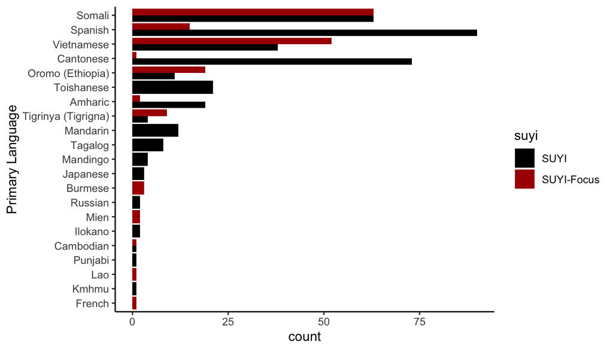

Bilingual Students

| Group | Total | Percent |
| --- | --- | --- |
| SUYI | 209 | 31.9 |
| SUYI-Focus | 86 | 38.0 |

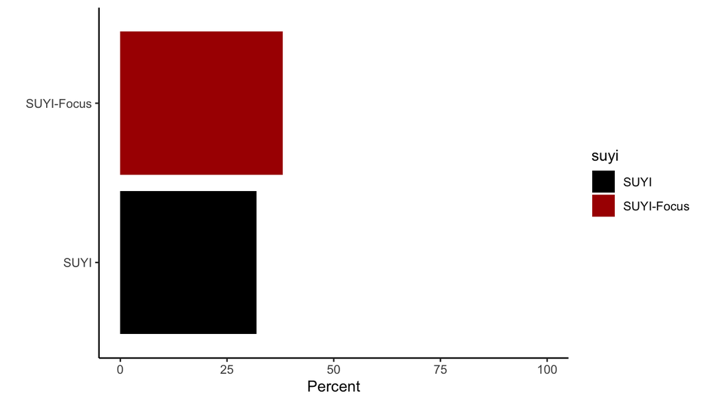

Students Experiencing Homelessness

| Group | Total | Percent |
| --- | --- | --- |
| SUYI | 52 | 7.94 |
| SUYI-Focus | 8 | 3.54 |

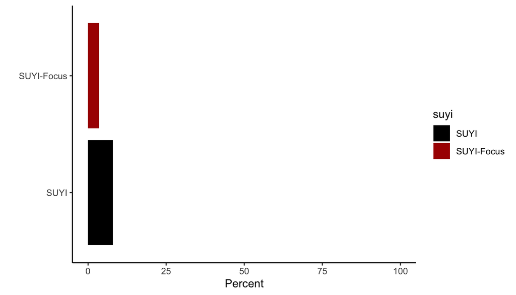

# Students Attendance

A student is considered “chronically absent” when they miss 15 or more days of instruction in one academic school year. Chronic absenteeism can lead to student’s missing important instructional time, ultimately causing students to fall behind in their academics. Furthermore, when students miss school they also miss important social interaction times that develop their interpersonal skills.

School Absenteeism

| Group | Min | Median | Mean | Max |
| --- | --- | --- | --- | --- |
| SUYI | 0 | 7 | 12.0 | 104 |
| SUYI-Focus | 0 | 8 | 13.5 | 118 |

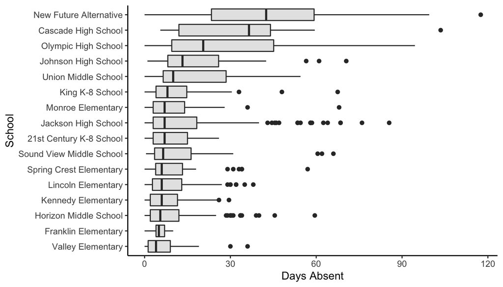

Elementary School Absenteeism

| School | Min | Median | Mean | Max |
| --- | --- | --- | --- | --- |
| King K-8 School | 1 | 8.5 | 12.78 | 67.5 |
| 21st Century K-8 School | 0 | 8.0 | 8.93 | 23.0 |
| Monroe Elementary | 0 | 7.0 | 10.13 | 68.0 |
| Kennedy Elementary | 0 | 6.0 | 7.88 | 29.5 |
| Lincoln Elementary | 0 | 6.0 | 8.89 | 38.0 |
| Spring Crest Elementary | 0 | 6.0 | 10.24 | 57.0 |
| Franklin Elementary | 0 | 5.0 | 5.42 | 10.0 |
| Valley Elementary | 0 | 4.0 | 6.51 | 36.0 |

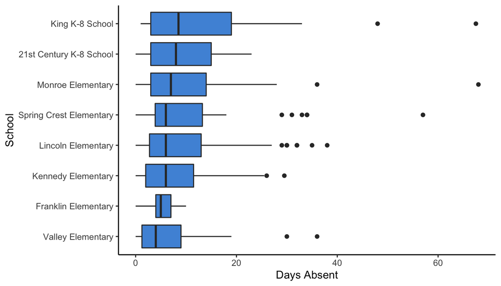

Middle School Absenteeism

| School | Min | Median | Mean | Max |
| --- | --- | --- | --- | --- |
| New Future Alternative | 15.0 | 23.0 | 21.67 | 27.0 |
| Union Middle School | 0.0 | 10.0 | 20.39 | 54.5 |
| King K-8 School | 0.0 | 8.0 | 10.57 | 30.5 |
| Sound View Middle School | 0.5 | 6.5 | 15.46 | 66.0 |
| 21st Century K-8 School | 2.0 | 6.0 | 9.65 | 26.0 |
| Horizon Middle School | 0.0 | 5.5 | 8.83 | 59.5 |

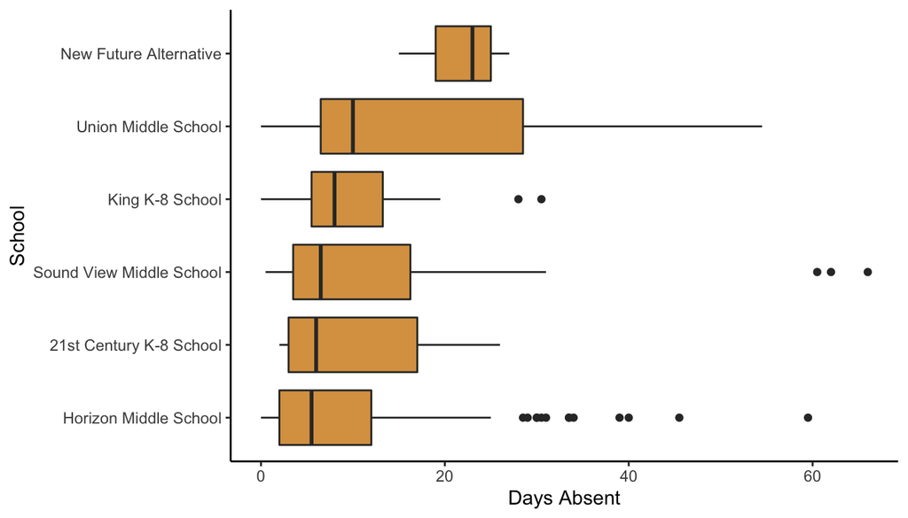

High School Absenteeism

| School | Min | Median | Mean | Max |
| --- | --- | --- | --- | --- |
| New Future Alternative | 0.0 | 48.5 | 47.8 | 117.5 |
| Cascade High School | 5.5 | 36.5 | 38.6 | 103.5 |
| Olympic High School | 0.0 | 20.5 | 30.7 | 94.5 |
| Johnson High School | 1.0 | 13.2 | 20.9 | 70.5 |
| Jackson High School | 0.0 | 7.0 | 14.4 | 85.5 |

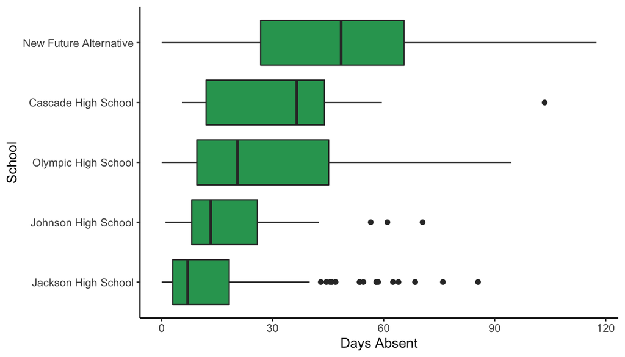

# RIT Scores

Fall Math Scores

| Group | Mean | Std. Err. | t-test |
| --- | --- | --- | --- |
| SUYI | 200 | 1.52 | n.s. |
| SUYI-Focus | 198 | 2.06 | n.s. |

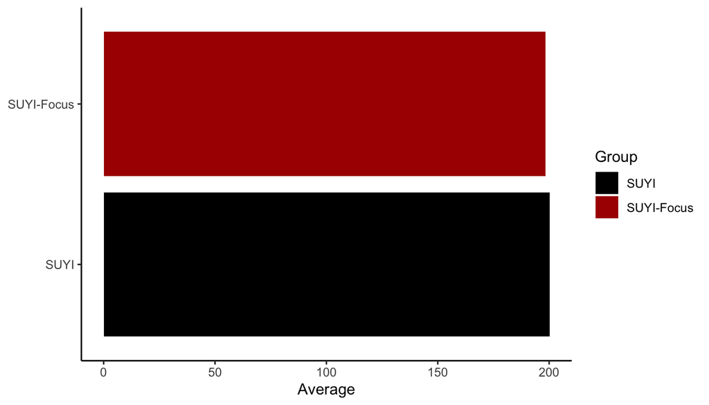

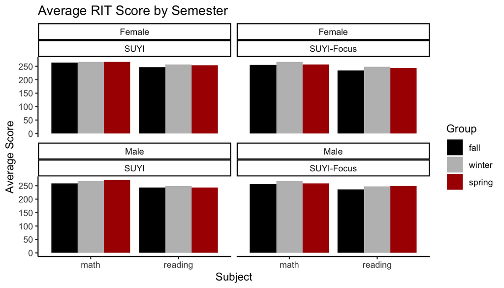

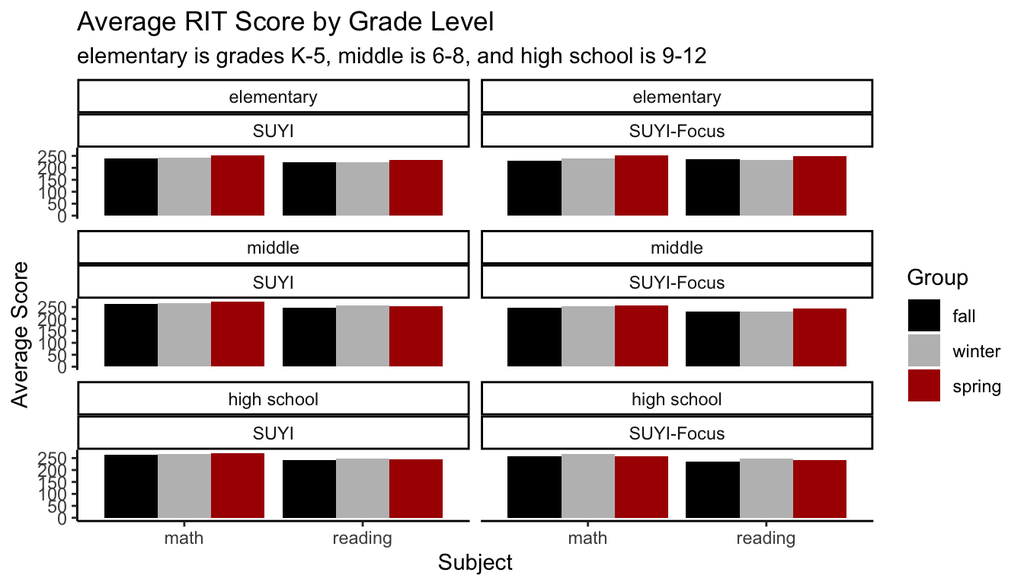

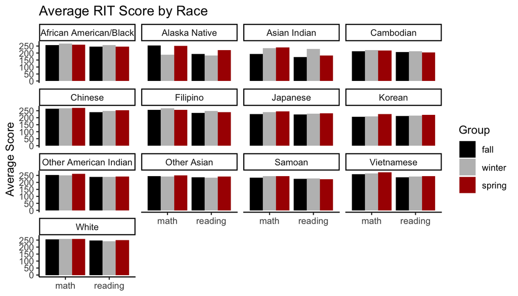

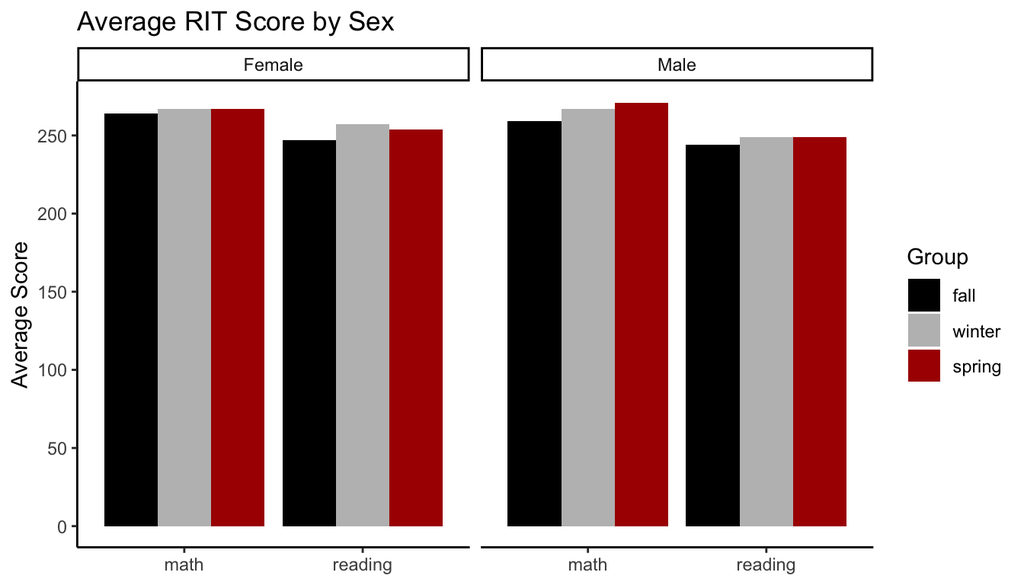

# Average RIT Elementary Schools

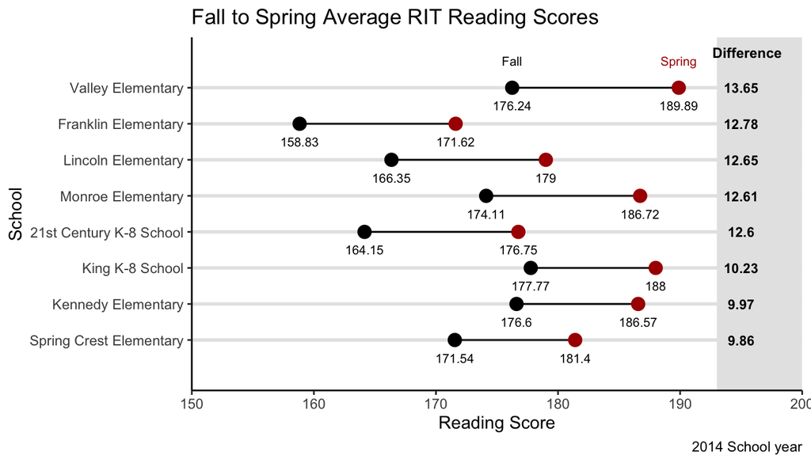

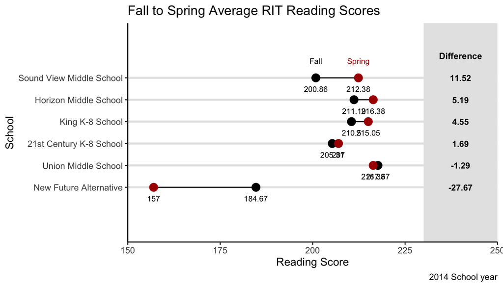

-Create a t-test to determine if being in the youth program affects students test scores versus those who are not in the program -Make tables to accompany each graph made - Find out what the national rit score is and then graph a line on the graph showing where SUYI fall within that range - Write up a summary of the findings